# Heart Disease Prediction

Rita Han

2022-11-23

# 1.0 Abstract

## Introduction

Modern days, people are busy with lives and satisfaction on materialistic needs, but neglect of body and mental health. This cause more and more heart suffer with various causes. Heart is the most crucial organ inside human body. Cardiovascular disease(heart disease) are #1 cause of death globally, which can take 17.9 million lives per year in estimation. This occupies 31% of all deaths worldwide.  
People with heart disease need early detection due to its high risk of death. In this case, machine learning model can be a great helper. Thus, I choose the heart failure prediction dataset to predict if someone is at high risk of being diagonised with heart disease. This dataset contains 11 features that can be used to predict possible heart disease. I first got to know the dataset and visualized it and then use cross-validation for the machine to better learn the data and to tune machine learning models: Random Forest, XGBoost, KNN, Decision Tree to compare which model perform the best on the train set in order prediction on the test set.

## Description of the Dataset

The Heart Failure Prediction Dataset was created by combining five different datasets with observations from different places among the world, with total 918 observations and 11 variables that can be possible predictors and our target variable ‘heart_disease’.  
-Age: age of the patient [years]  
-Sex: sex of the patient [M: Male, F: Female]  
-ChestPainType: chest pain type [TA: Typical Angina, ATA: Atypical Angina, NAP: Non-Anginal Pain, ASY: Asymptomatic]  
-RestingBP: resting blood pressure [mm Hg]  
-Cholesterol: serum cholesterol [mm/dl]  
-FastingBS: fasting blood sugar [1: if FastingBS > 120 mg/dl, 0: otherwise]  
-RestingECG: resting electrocardiogram results [Normal: Normal, ST: having ST-T wave abnormality (T wave inversions and/or ST elevation or depression of > 0.05 mV), LVH: showing probable or definite left ventricular hypertrophy by Estes’ criteria]  
-MaxHR: maximum heart rate achieved [Numeric value between 60 and 202]  
-ExerciseAngina: exercise-induced angina [Y: Yes, N: No]  
-Oldpeak: oldpeak = ST [Numeric value measured in depression]  
-ST_Slope: the slope of the peak exercise ST segment [Up: upsloping, Flat: flat, Down: downsloping]  
-HeartDisease: output class [1: heart disease, 0: Normal]

```r
#input file and use clean_names() function to put variables into a clear format
heart = read_csv("/Users/ritahan/Desktop/pstat131/heart.csv") %>%
  clean_names()
#display the first couple lines of the dataset
heart$heart_disease=as.character(heart$heart_disease)
heart$fasting_bs=as.character(heart$fasting_bs)
heart= heart %>%
  filter(heart$cholesterol != 0)
```

```r
heart=heart %>%
  mutate(fasting_bs=factor(fasting_bs),
         heart_disease=factor(heart_disease),
         chest_pain_type=factor(chest_pain_type),
         resting_ecg=factor(resting_ecg),
         exercise_angina=factor(exercise_angina))
heart %>%
  head()
```

```
## # A tibble: 6 × 12
##     age sex   chest_pai…¹ resti…² chole…³ fasti…⁴ resti…⁵ max_hr exerc…⁶ oldpeak
##   <dbl> <chr> <fct>         <dbl>   <dbl> <fct>   <fct>    <dbl> <fct>     <dbl>
## 1    40 M     ATA             140     289 0       Normal     172 N           0
## 2    49 F     NAP             160     180 0       Normal     156 N           1
## 3    37 M     ATA             130     283 0       ST          98 N           0
## 4    48 F     ASY             138     214 0       Normal     108 Y           1.5
## 5    54 M     NAP             150     195 0       Normal     122 N           0
## 6    39 M     NAP             120     339 0       Normal     170 N           0
## # … with 2 more variables: st_slope <chr>, heart_disease <fct>, and abbreviated
## #   variable names ¹chest_pain_type, ²resting_bp, ³cholesterol, ⁴fasting_bs,
## #   ⁵resting_ecg, ⁶exercise_angina
```

```r
heart %>%
  summary()
```

```
##       age            sex            chest_pain_type   resting_bp
##  Min.   :28.00   Length:746         ASY:370         Min.   : 92
##  1st Qu.:46.00   Class :character   ATA:166         1st Qu.:120
##  Median :54.00   Mode  :character   NAP:169         Median :130
##  Mean   :52.88                      TA : 41         Mean   :133
##  3rd Qu.:59.00                                      3rd Qu.:140
##  Max.   :77.00                                      Max.   :200
##   cholesterol    fasting_bs resting_ecg      max_hr      exercise_angina
##  Min.   : 85.0   0:621      LVH   :176   Min.   : 69.0   N:459
##  1st Qu.:207.2   1:125      Normal:445   1st Qu.:122.0   Y:287
##  Median :237.0              ST    :125   Median :140.0
##  Mean   :244.6                           Mean   :140.2
##  3rd Qu.:275.0                           3rd Qu.:160.0
##  Max.   :603.0                           Max.   :202.0
##     oldpeak          st_slope         heart_disease
##  Min.   :-0.1000   Length:746         0:390
##  1st Qu.: 0.0000   Class :character   1:356
##  Median : 0.5000   Mode  :character
##  Mean   : 0.9016
##  3rd Qu.: 1.5000
##  Max.   : 6.2000
```

I first make ‘heart_disease and ’fasting_bs’ to characters, then it’s easy to mutate all characteristic variables to factors for further prediction. I filtered out the observations with cholesterol equal to 0. Obtain a cholesterol equal to 0 is very rare, so we can regard these as no observation. Thus, filter them out for further analysis might be a good idea.

# 2.0 EDA

The data is already a cleaned one! Let’s get a deeper understanding of the dataset, I first visualized the distribution of the ‘1’ and ‘0’ from ‘heart_disease’. Then, I made a correlation heatmap for all numeric variables to see if there is any interesting correlations. Next, I visualize the numeric variables with density plots fill by heart_disease, which can easily see the relationship between each numeric variable and heart disease. And, for categorical variables, I used barplot fill by ‘heart_disease’ and boxplot to explore some interesting relationships.  
## heart_disease count

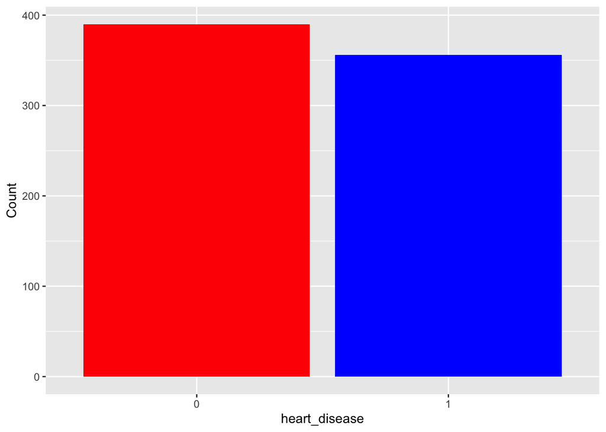

```r
heartdisease_counting <- heart %>%
    group_by(heart_disease) %>%
    summarise(Count = n())

ggplot(data = heartdisease_counting, aes(x = heart_disease,
                                         y = Count)) +
    geom_histogram(stat = "identity", fill = c("red", "blue"))
```

```r
percent_heartdisease <- percent(heartdisease_counting$Count[1]/sum(heartdisease_counting$Count),
    accuracy = 0.01)
percent_heartdisease
```

```
## [1] "52.28%"
```

## correlations

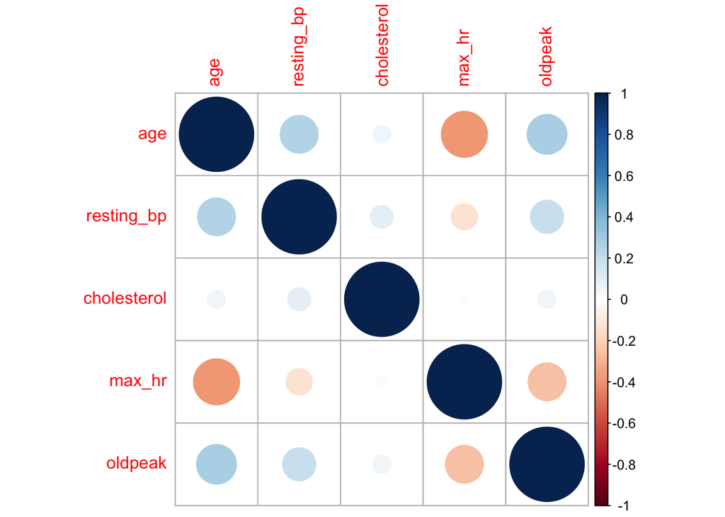

```r
heart %>%
  select(is.numeric) %>%
  cor() %>%
  corrplot()
```

## Numerical variables

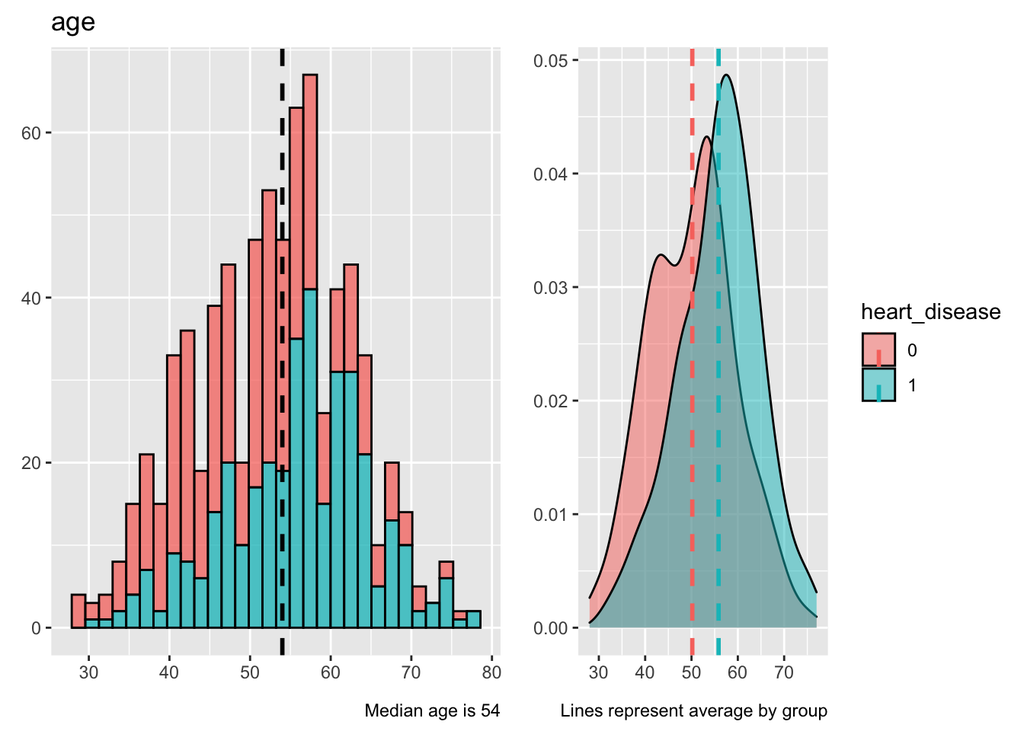

```r
plot_histogram <- function(df, var1, var2) {
    # From object to string: deparse(substitute(varname))
    var1name <- as.name(var1)
    df %>%
        ggplot(aes(x = {
            {
                var1name
            }
        }, fill = {
            {
                var2
            }
        })) + geom_histogram(alpha = 0.75, position = "stack",
        color = "black", bins = 30) + geom_vline(aes(xintercept = median({
        {
            var1name
        }
    })), linetype = 2, size = 1) + labs(caption = paste0("Median ",
        {
            {
                var1
            }
        }, " is ", round(median({
            {
                df
            }
        }[[{
            {
                var1
            }
        }]]), 2)), y = element_blank(), x = element_blank(),
        title = paste0({
            {
                var1
            }
        })) + theme(legend.position = "none")
}

plot_density <- function(df, var1, var2) {
    var1name <- as.name(var1)
    df %>%
        ggplot(aes(x = {
            {
                var1name
            }
        }, fill = {
            {
                var2
            }
        })) + geom_density(alpha = 0.5, color = "black") + geom_vline(data = df %>%
        group_by({
            {
                var2
            }
        }) %>%
        summarize(mean.grp = mean({
            {
                var1name
            }
        })), aes(xintercept = mean.grp, color = heart_disease), linetype = "dashed",
        size = 1) + labs(caption = paste0("Lines represent average by group"),
        y = element_blank(), x = element_blank(), title = "")
}

plot_2plots <- function(df, var1, var2) {
    p1 <- plot_histogram({
        {
            df
        }
    }, {
        {
            var1
        }
    }, {
        {
            var2
        }
    })
    p2 <- plot_density({
        {
            df
        }
    }, {
        {
            var1
        }
    }, {
        {
            var2
        }
    })

    grid.arrange(p1, p2, ncol = 2)

}
plot_2plots(heart, "age", heart_disease)
```

From the age plots, we can easily see that heart disease occur more on old people.

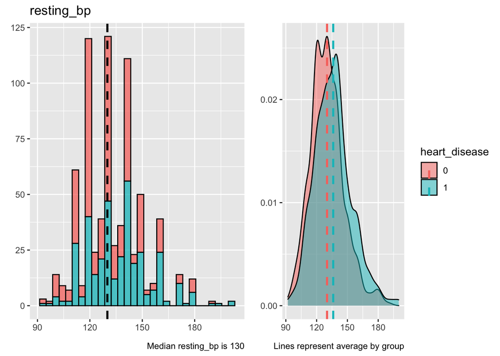

```r
plot_2plots(heart, "resting_bp", heart_disease)
```

From the resting_bp plots, we can see that when resting blood pressure is between 100-150 mmhg, the occurance of heart-disdease is basically half-half; but when exceeding 150mmhg, the occurance of heart-disease increases a little.

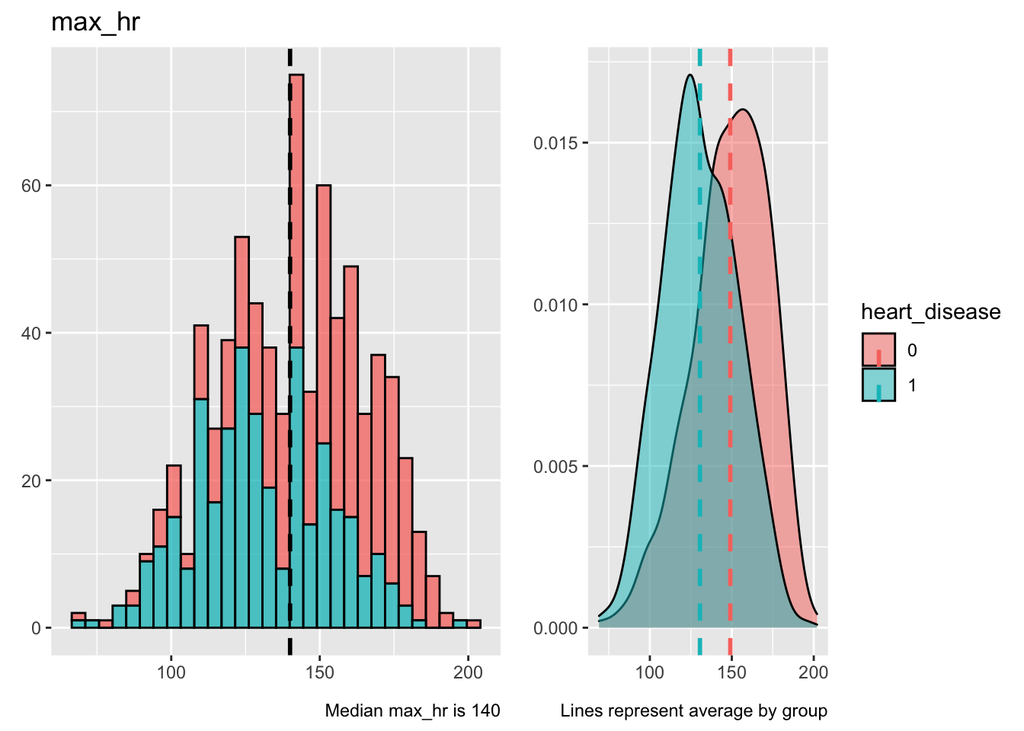

```r
plot_2plots(heart, "max_hr", heart_disease)
```

From the max_hr graphs, there is a negative correlation between max_hr and heart_disease. People who acheive higher heart rate have less probibility to get heart disease.

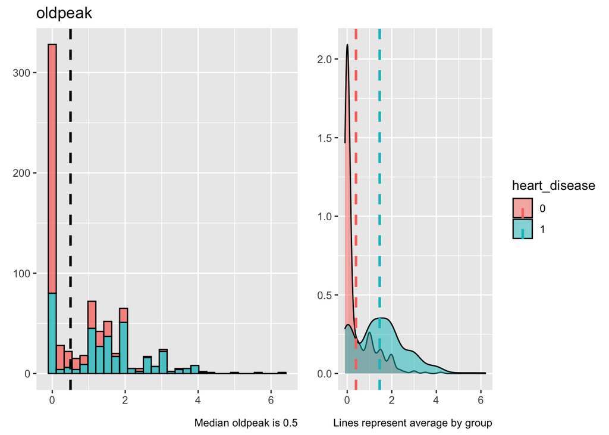

```r
plot_2plots(heart, "oldpeak", heart_disease)
```

‘Oldpeak’ means a depressed/lower line on an ECG induced by exercise. We can easily see that people with high oldpeak get heart disease more than people with low oldpeak.

## Categorical variables

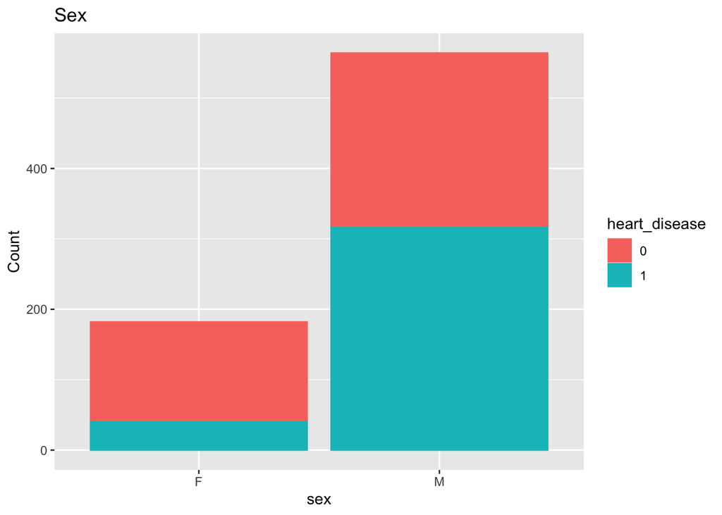

```r
#barplot of sex fill by heart_disease
options(repr.plot.width = 10, repr.plot.height = 10)
ggplot(heart) + geom_bar(aes(x = sex, color = heart_disease,
    fill = heart_disease)) + ggtitle("Sex") + labs(x = "sex",
    y = "Count")
```

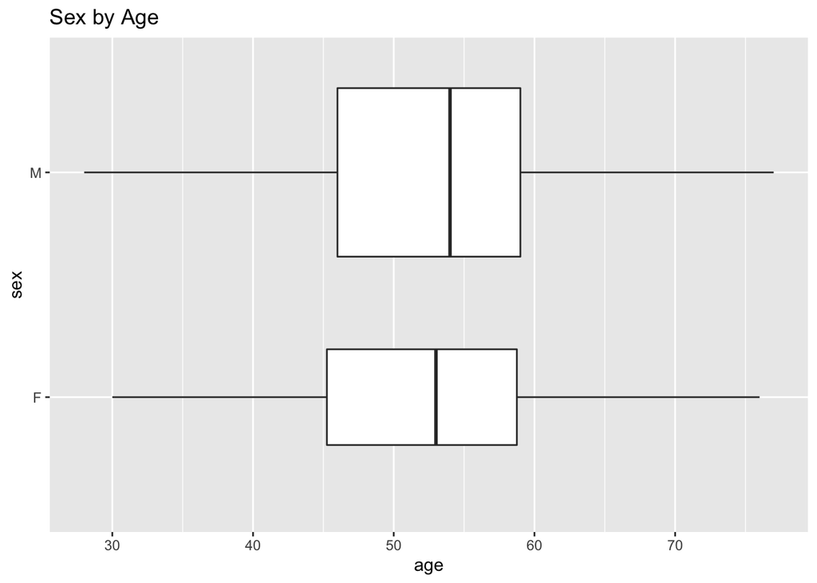

```r
#boxplot of sex and age
ggplot(heart, aes(reorder(sex, age), age)) +
  geom_boxplot(varwidth = TRUE) +
  coord_flip() +
  labs(
    title = "Sex by Age",
    x = "sex"
  )
```

From the Sex graph, the observations of male is much higher than the one of female. Thus, we only concentrate on the heart disease proportion for each sex. Male with heart disease have slightly higher proportion among all male, but female with heart disease have a much lower proportion among all female. Also, with the help from sex by age boxplot, we see that the observations of male and female are basically selected from the same age range. Thus, we can conclude that, according to this dataset, male is much likely to get heart disease.

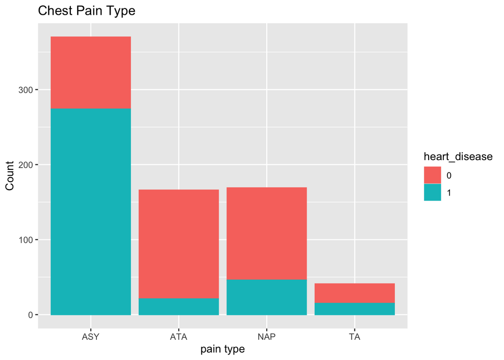

```r
#barplot of chest pain type fill by heart_disease
options(repr.plot.width = 10, repr.plot.height = 10)
ggplot(heart) + geom_bar(aes(x = chest_pain_type, color = heart_disease,
    fill = heart_disease)) + ggtitle("Chest Pain Type") + labs(x = "pain type",
    y = "Count")
```

The graph chest pain type above clearly shows ‘ASY’ chest pain type has a high probobility to cause heart disease, but the others are not likewise; especially, ‘ATA’ and ‘NAP’ are less likely to cause heart disease. The observasions of ‘TA’ is fewer, but the proportion of causing heart disease or not is close to 50%.

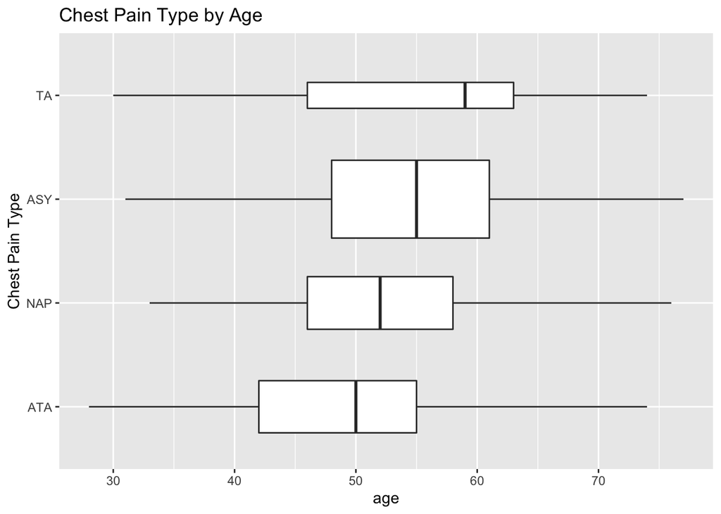

```r
#boxplot of chest pain type and age
ggplot(heart, aes(reorder(chest_pain_type, age), age)) +
  geom_boxplot(varwidth = TRUE) +
  coord_flip() +
  labs(
    title = "Chest Pain Type by Age",
    x = "Chest Pain Type"
  )
```

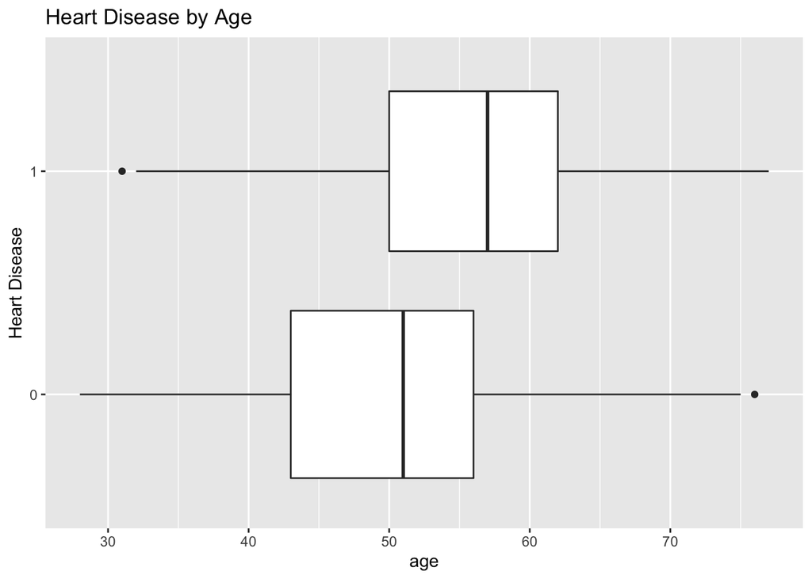

```r
#boxplot of heart-disease and age
ggplot(heart, aes(reorder(heart_disease, age), age)) +
  geom_boxplot(varwidth = TRUE) +
  coord_flip() +
  labs(
    title = "Heart Disease by Age",
    x = "Heart Disease"
  )
```

The ‘chest pain type by age’ graph and the ‘heart disease by age’ graph both supports the result from the previous chest pain type bar plot. Age can be an important cause of heart disease. Older people are more likely have heart disease than younger ones. Moreover, the ‘ATA’ and ‘NAP’ are seen more in younger people. Thus, these two types are less likely to relate to heart disease. ‘TA’ and ‘ASY’ occur more on older people. Thus, they have a higher relation to heart disease. And since, both ‘TA’ and ‘ASY’ are roughly ranged between age of 50-60, we can conclude that age of 50-60 might be a common period to get heart disease.

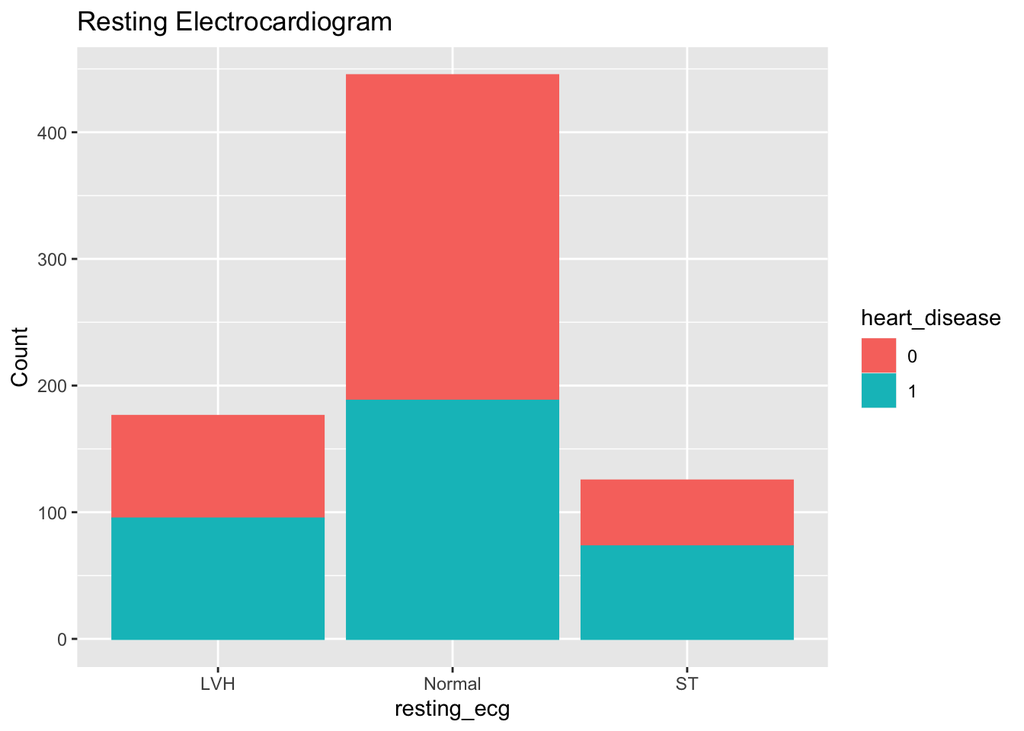

```r
#barplot of restingECG fill by heart_disease
options(repr.plot.width = 10, repr.plot.height = 10)
ggplot(heart) + geom_bar(aes(x = resting_ecg, color = heart_disease,
    fill = heart_disease)) + ggtitle("Resting Electrocardiogram") + labs(x = "resting_ecg",
    y = "Count")
```

From the resting electrocardiogram barplot, base on this particular dataset, we can conclude that people with normal restingECG have a slightly lower proportion of having heart disease, people with ‘LVH’,‘ST’ have a higher proportion of having heart disease, which make sense because normal resting ECG means the heart is at a relatively good condition.

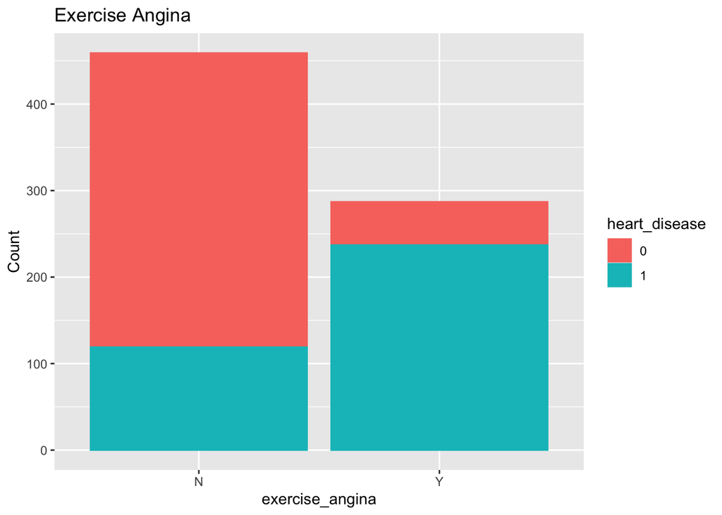

```r
#barplot of exerciseangina fill by heart_disease
options(repr.plot.width = 10, repr.plot.height = 10)
ggplot(heart) + geom_bar(aes(x = exercise_angina, color = heart_disease,
    fill = heart_disease)) + ggtitle("Exercise Angina") + labs(x = "exercise_angina",
    y = "Count")
```

From the Exercise angina graph, it is obvious that people with exercise induced angina are much more likely to have heart disease. Angina occurs when the heart needs more oxygen-rich blood but the demand is not met, which can be a big influencer of heart disease.

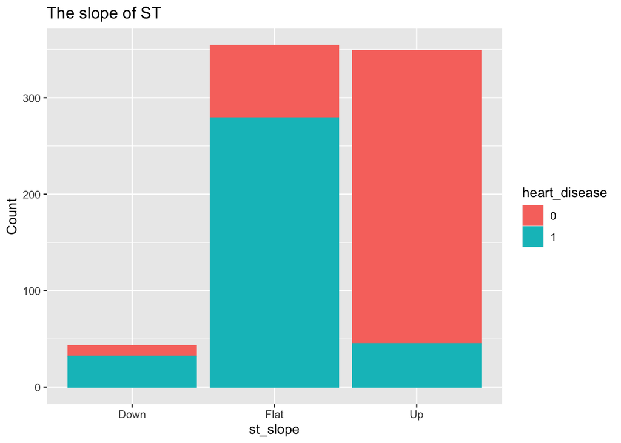

```r
#barplot of st_slope fill by heart_disease
options(repr.plot.width = 10, repr.plot.height = 10)
ggplot(heart) + geom_bar(aes(x = st_slope, color = heart_disease,
    fill = heart_disease)) + ggtitle("The slope of ST") + labs(x = "st_slope",
    y = "Count")
```

From the slope of ST graph, we see that upward slope is less likely to be related to heart disease, however, flat and downward slope have a high relationship with heart disease.  
Thus, we can conclude from the EDA section that Age is a important factor that influence the target variable and also other variables, except ‘cholesterol’ which isn’t really influenced by age, however, other variables doesn’t really correlate with each other.

# 3.0 Set Up for Model Building

With a deeper understanding of the data, we are going to prepare for the model building. I first split the data into train and test set, make a recipe and do a cross-validation for resampling.  
## train and testing split

```r
heart_split <- heart %>%
  initial_split(prop = 0.8, strata = "heart_disease")

heart_train <- training(heart_split)
heart_test <- testing(heart_split)
```

```r
dim(heart_train)
```

```
## [1] 596  12
```

```r
dim(heart_test)
```

```
## [1] 150  12
```

There are 596 observations in the train set, and 150 observations in the test set. Stratified sampling was used on the response variable ‘heart_disease’.

## Recipe Building

We will create the recipe with dummy-coding categorical variables, and center and scale all predictors for model usage.

```r
heart_recipe=recipe(heart_disease ~ . , data=heart_train) %>%
  step_dummy(all_nominal_predictors()) %>%
  step_normalize(all_predictors())
```

## K-Fold Cross Validation

```r
heart_folds <- vfold_cv(heart_train, v = 10, strata = heart_disease)  # 10-fold CV
```

# 3.0Model Building

We are ready for model building! The four model I used are Random Forest, XGBoost, KNN, Decision Tree. I first tried to create a regular grid to tune the random forest, and then tried to let the tidymodel tune by default. After comparing the result, they are both time-consuming, especially when I specified to a higher level, and the result is really close, so I decided to choose tuning by default.

## Random Forest

```r
rf_model <-
  rand_forest() %>%
  set_engine("randomForest") %>%
  set_mode("classification") %>%
  set_args(mtry = tune(), trees = tune(), min_n = tune())
```

```r
rf_wf <-
  workflow() %>%
  add_model(rf_model) %>%
  add_recipe(heart_recipe)
rf_wf
```

```
## ══ Workflow ════════════════════════════════════════════════════════════════════
## Preprocessor: Recipe
## Model: rand_forest()
##
## ── Preprocessor ────────────────────────────────────────────────────────────────
## 2 Recipe Steps
##
## • step_dummy()
## • step_normalize()
##
## ── Model ───────────────────────────────────────────────────────────────────────
## Random Forest Model Specification (classification)
##
## Main Arguments:
##   mtry = tune()
##   trees = tune()
##   min_n = tune()
##
## Computational engine: randomForest
```

Create regular grid to tune with specified ranges.

```r
# rf_grid=grid_regular(mtry(range = c(2,10)),
#                              trees(range = c(100, 1300)),
#                              min_n(range = c(5, 35)),
#                              levels = 4)
```

```r
# rf_tune=tune_grid(rf_wf,
#                   resamples=heart_folds,
#                   grid=rf_grid,
#                   metrics=metric_set(accuracy))
```

I save the rf_grid, rf_tune into a rda for time-saving

```r
#save(rf_grid, rf_tune, file=
#       "/Users/ritahan/Desktop/pstat131/rfgrid.rda")
```

```r
load("/Users/ritahan/Desktop/pstat131/rfgrid.rda")
```

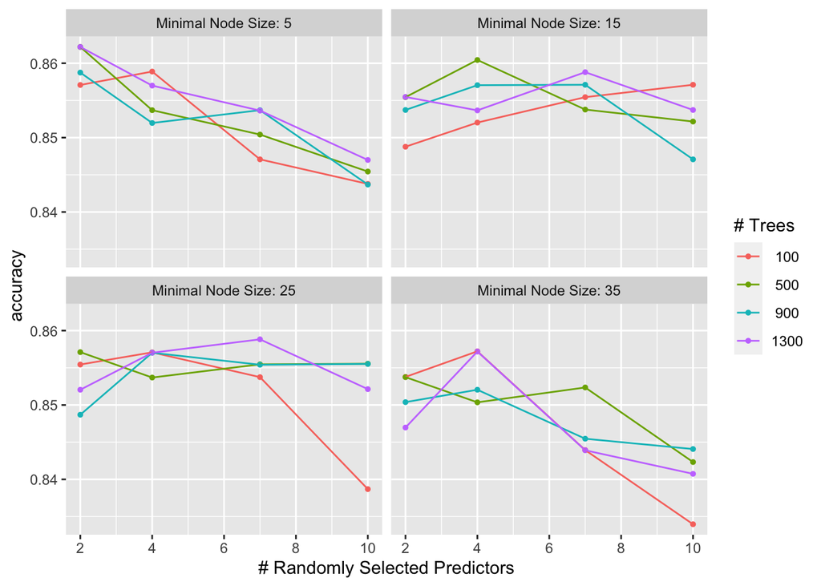

```r
autoplot(rf_tune)
```

```r
rf_tune_final <- rf_tune %>%
  select_best(metric = "accuracy")
rf_tune_final
```

```
## # A tibble: 1 × 4
##    mtry trees min_n .config
##   <int> <int> <int> <chr>
## 1     2  1300     5 Preprocessor1_Model13
```

```r
rf_tune_wf <- rf_wf %>%
  finalize_workflow(rf_tune_final)
rf_tune_wf
```

```
## ══ Workflow ════════════════════════════════════════════════════════════════════
## Preprocessor: Recipe
## Model: rand_forest()
##
## ── Preprocessor ────────────────────────────────────────────────────────────────
## 2 Recipe Steps
##
## • step_dummy()
## • step_normalize()
##
## ── Model ───────────────────────────────────────────────────────────────────────
## Random Forest Model Specification (classification)
##
## Main Arguments:
##   mtry = 2
##   trees = 1300
##   min_n = 5
##
## Computational engine: randomForest
```

```r
#fitting the final workflow to the train set(create regular grid to tune)
rf_tune_fit=fit(rf_tune_wf, heart_train)
#accuracy of rf model
rf_tune_acc <- predict(rf_tune_fit, new_data = heart_train, type = "class") %>%
  bind_cols(heart_train %>%
              select(heart_disease)) %>%
  accuracy(truth = heart_disease, estimate = .pred_class)
rf_tune_acc
```

```
## # A tibble: 1 × 3
##   .metric  .estimator .estimate
##   <chr>    <chr>          <dbl>
## 1 accuracy binary         0.928
```

rf on test set

```r
rf_tune_acc_test <- predict(rf_tune_fit, new_data = heart_test,
                            type = "class") %>%
  bind_cols(heart_test %>%
              select(heart_disease)) %>%
  accuracy(truth = heart_disease, estimate = .pred_class)
rf_tune_acc_test
```

```
## # A tibble: 1 × 3
##   .metric  .estimator .estimate
##   <chr>    <chr>          <dbl>
## 1 accuracy binary         0.893
```

Next, I will try do not create grid and let ‘tidymodel’ to chose the range for parameters by default.

```r
rf_results <-
  rf_wf %>%
  tune_grid(resamples = heart_folds,
            metrics = metric_set(accuracy)
  )
```

```
## i Creating pre-processing data to finalize unknown parameter: mtry
```